# Biostat M280 Homework 4

```r
lax_weekly <- flights_tbl %>%
  select(origin, dest, year, dayofweek) %>%
  filter(dest == "LAX" | origin == "LAX") %>%
  filter(year >= 1998 && year <= 2008) %>%
  group_by(year, dayofweek) %>%
  summarise(n = n()) %>%
  arrange(year, dayofweek) %>%
  collect()

lax_weekly
```

```
## # A tibble: 77 x 3
## # Groups:   year [11]
##     year dayofweek      n
##    <int>     <int>  <dbl>
##  1  1998         1 53843.
##  2  1998         2 53740.
##  3  1998         3 53727.
##  4  1998         4 54377.
##  5  1998         5 53378.
##  6  1998         6 47642.
##  7  1998         7 51500.
##  8  1999         1 56214.
##  9  1999         2 56367.
## 10  1999         3 56409.
## # ... with 67 more rows
```

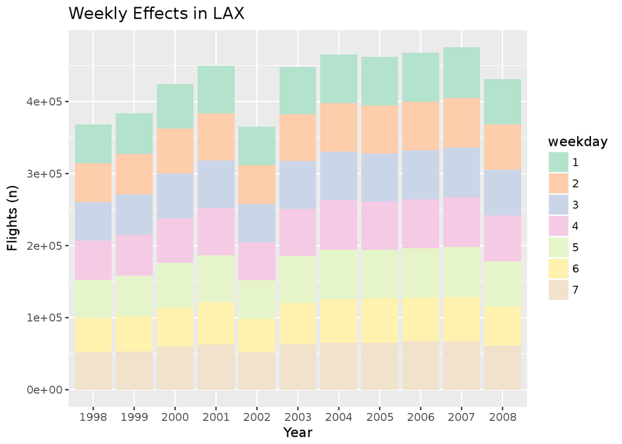

```r
lax_weekly$dayofweek <- as.factor(lax_weekly$dayofweek)
colnames(lax_weekly)[2] <-"weekday"
ggplot(lax_weekly) +
  geom_col(aes(x = as.factor(year), y = n, fill = weekday),
           position = "stack") +
  scale_fill_brewer(palette = "Pastel2") +
  labs(x = "Year", y = "Flights (n)",
       title = "Weekly Effects in LAX")
```

```
(d). Map top 10 destinations from LAX. Size of dots should reflect the number of flights from LAX to that destination.
```

```r
# top 10 destinations
lax_top <- flights_tbl %>%
  filter(origin == "LAX" & !is.na(dest)) %>%
  select(origin, dest) %>%
  group_by(dest) %>%
  tally() %>%
  arrange(desc(n)) %>%
  collect() %>%
  top_n(10)
write_rds(lax_top, "lax_top.rds")

options(digits = 15)

lax_top_dest <- lax_top %>%
  left_join(airports_tbl, by = c("dest" = "faa"), copy = TRUE) %>%
  select(dest, n, lon, lat) %>%
  mutate(
    lon = as.double(lon),
    lat = as.double(lat)) %>%
  collect()

lax_top_dest
```

```
## # A tibble: 10 x 4
##    dest        n    lon   lat
##    <chr>   <dbl>  <dbl> <dbl>
##  1 SFO   336938. -122.   37.6
##  2 LAS   292125. -115.   36.1
##  3 PHX   279116. -112.   33.4
##  4 OAK   190549. -122.   37.7
##  5 ORD   189419.  -87.9  42.0
##  6 SAN   168302. -117.   32.7
##  7 SJC   163624. -122.   37.4
##  8 SEA   157824. -122.   47.4
##  9 JFK   155991.  -73.8  40.6
## 10 DFW   139732.  -97.0  32.9
```

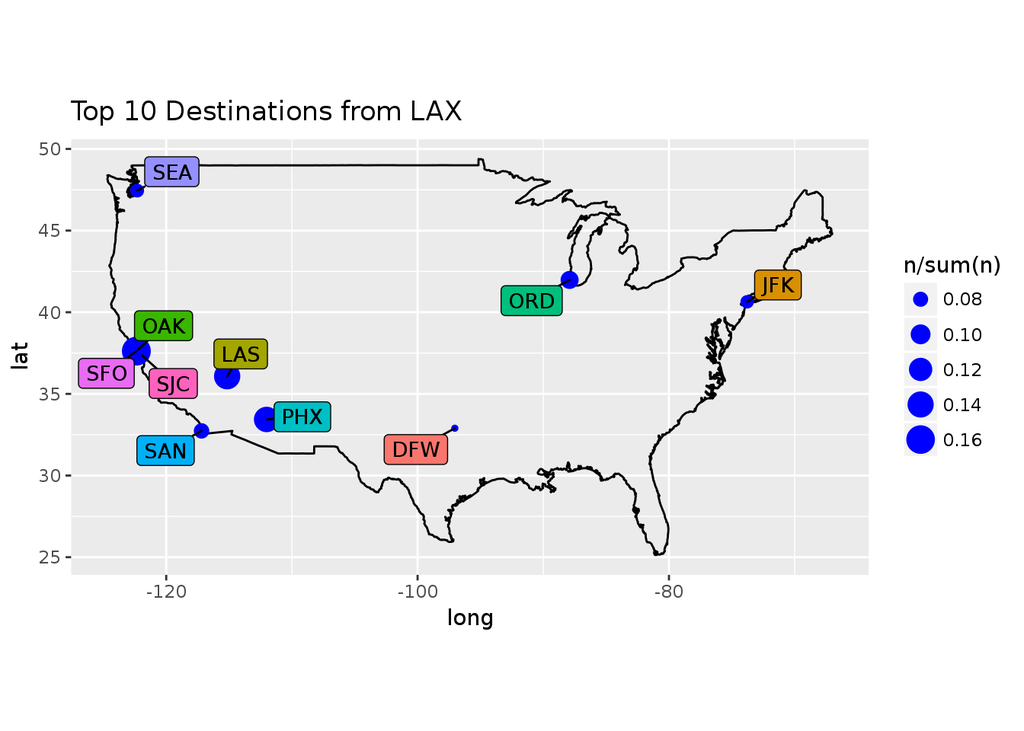

[output not shown]

```r
usa <- map_data("usa")

us_map1 <- ggplot() +
  geom_polygon(data = usa, aes(x = long, y = lat, group = group), fill = NA, color = "black") +
  coord_fixed(1.3) +
  guides(fill=FALSE)

us_map1 <- us_map1 +
  geom_point(data = lax_top_dest,
             aes(x = lon, y = lat, size = n/sum(n)),
             color = "blue")

us_map1 <- us_map1 +
  geom_label_repel(data = lax_top_dest,
                   aes(x = lon, y = lat, label = dest, size = n/sum(n),
                       fill = factor(dest)), min.segment.length = 0,
                   size = 3.5) +
  ggtitle("Top 10 Destinations from LAX")

us_map1
```

**4. Build a predictive model for the arrival delay (`arrdelay`) of flights flying from LAX. Use the same filtering criteria as in the [lecture notes](http://hua-zhou.github.io/teaching/biostatm280-2018winter/slides/12-sparklyr/sparklyr-flights.html) to construct training and validation sets. You are allowed to use a maximum of 5 predictors. The prediction performance of your model on the validation data set will be an important factor for grading this question.**

```r
  model_data1 <- flights_tbl %>%
  filter(origin == "LAX") %>%
    filter(!is.na(arrdelay) & !is.na(depdelay) & !is.na(distance) &!is.na(deptime) &!is.na(airtime)) %>%
    filter(depdelay > 15 & depdelay < 240) %>%
    filter(arrdelay > -60 & arrdelay < 360) %>%
    filter(year >= 2003 & year <= 2007) %>%
    left_join(airlines_tbl, by = c("uniquecarrier" = "code")) %>%
    select(year, month, arrdelay, depdelay, distance, uniquecarrier, description, deptime, airtime)

model_data1
```

```
## # Source:   lazy query [?? x 9]
## # Database: spark_connection
##     year month arrdelay depdelay distance uniquecarrier description
##    <int> <int>    <int>    <int>    <int> <chr>         <chr>
##  1  2003     1       56       49     1745 UA            United Air Lines …
##  2  2003     1      205      210      373 UA            United Air Lines …
##  3  2003     1       70       84      834 UA            United Air Lines …
##  4  2003     1        3       19      834 UA            United Air Lines …
##  5  2003     1       36       44      862 UA            United Air Lines …
##  6  2003     1       14       18      862 UA            United Air Lines …
##  7  2003     1       22       32      862 UA            United Air Lines …
##  8  2003     1        6       18      862 UA            United Air Lines …
##  9  2003     1       49       34      862 UA            United Air Lines …
## 10  2003     1       10       19     1671 UA            United Air Lines …
## # ... with more rows, and 2 more variables: deptime <int>, airtime <chr>
```

```r
# Summarize data by carrier
model_data1 %>%
  filter(origin == "LAX") %>%
  group_by(uniquecarrier) %>%
  summarize(description = min(description), distance = mean(distance), arrdelay = mean(arrdelay), depdelay = mean(depdelay)) %>%
  select(description, distance, arrdelay, depdelay)
```

```
## # Source:   lazy query [?? x 4]
## # Database: spark_connection
## # ... with 4 variables: description <chr>, distance <dbl>, arrdelay <dbl>,
## #   depdelay <dbl>
```

```r
model_data1
```

```
## # Source:   lazy query [?? x 9]
## # Database: spark_connection
##     year month arrdelay depdelay distance uniquecarrier description
##    <int> <int>    <int>    <int>    <int> <chr>         <chr>
##  1  2003     1       56       49     1745 UA            United Air Lines …
##  2  2003     1      205      210      373 UA            United Air Lines …
##  3  2003     1       70       84      834 UA            United Air Lines …
##  4  2003     1        3       19      834 UA            United Air Lines …
##  5  2003     1       36       44      862 UA            United Air Lines …
##  6  2003     1       14       18      862 UA            United Air Lines …
##  7  2003     1       22       32      862 UA            United Air Lines …
##  8  2003     1        6       18      862 UA            United Air Lines …
##  9  2003     1       49       34      862 UA            United Air Lines …
## 10  2003     1       10       19     1671 UA            United Air Lines …
## # ... with more rows, and 2 more variables: deptime <int>, airtime <chr>
```

```r
model_partition1 <- model_data1 %>%
  sdf_partition(train = 0.8, valid = 0.2, seed = 5555)

# Fit a linear model
  ml2 <- model_partition1$train %>%
    ml_linear_regression(arrdelay ~ distance + depdelay + uniquecarrier)

# Summarize the linear model
summary(ml2)
```

```
## Call: ml_linear_regression.tbl_spark(., arrdelay ~ distance + depdelay + uniquecarrier)
##
## Deviance Residuals (approximate):
##              Min               1Q           Median               3Q
## -156.69684663245   -7.10864044376   -1.39888105748    5.20284831469
##              Max
##  277.53278407001
##
## Coefficients:
##          (Intercept)             distance             depdelay
## -1.10294544766340907 -0.00299794766776571  1.01320872212220658
##     uniquecarrier_WN     uniquecarrier_OO     uniquecarrier_AA
## -1.61794338787519587  1.08141553733928553  3.70525612176232588
##     uniquecarrier_UA     uniquecarrier_DL     uniquecarrier_AS
##  1.49608963947700646  3.78964158649730676  0.38460088089151911
##     uniquecarrier_MQ     uniquecarrier_CO     uniquecarrier_NW
##  0.50299964656095464  5.20990986281637625  1.31159011653107238
##     uniquecarrier_US     uniquecarrier_HP     uniquecarrier_XE
##  2.25736938095445838  0.62656398744581687  2.29937932164247094
##     uniquecarrier_F9     uniquecarrier_TZ     uniquecarrier_FL
##  2.22503576716205531  5.60172436934775231  3.14184604981943094
##     uniquecarrier_EV     uniquecarrier_YV     uniquecarrier_HA
##  1.21261304163933259  0.69989292036565431 -0.18656685632009054
##     uniquecarrier_DH
## 15.37347023375828314
##
## R-Squared: 0.8851
## Root Mean Squared Error: 13.33
```

80% of the flight data was used for training and 20% of the data was set aside for testing (prediction). Three predictor variables (distance, departure delay and unique carrier) were used to predict the outcome variable (arrival delay). Output shows values of coefficients.

```r
#Test data
test_flights_2008 <- flights_tbl %>%
  filter(origin == "LAX") %>%
    filter(!is.na(arrdelay) & !is.na(depdelay) & !is.na(distance)) %>%
  filter(depdelay > 15 & depdelay < 240) %>%
  filter(arrdelay > -60 & arrdelay < 360) %>%
  filter(year == 2008) %>%
  left_join(airlines_tbl, by = c("uniquecarrier" = "code")) %>%
    select(year, month, arrdelay, depdelay,
           distance, uniquecarrier, description)

head(test_flights_2008)
```

```
## # Source:   lazy query [?? x 7]
## # Database: spark_connection
##    year month arrdelay depdelay distance uniquecarrier description
##   <int> <int>    <int>    <int>    <int> <chr>         <chr>
## 1  2008     1       15       25      677 WN            Southwest Airlines…
## 2  2008     1       32       40      677 WN            Southwest Airlines…
## 3  2008     1       42       52     1797 WN            Southwest Airlines…
## 4  2008     1       22       32     1797 WN            Southwest Airlines…
## 5  2008     1       96      110      714 WN            Southwest Airlines…
## 6  2008     1       15       20      714 WN            Southwest Airlines…
```

```r
#prediction values

  test_flights_2008 <- sdf_predict(test_flights_2008, ml2) %>%
    mutate(mse_sum = (prediction - arrdelay)^2) %>%
    collect

#calculate root mse by calculating sqrt(sum(y(predicted) - y(observed))^2/n)

  root_mse <- sqrt(sum(test_flights_2008$mse_sum) / count(test_flights_2008))
  root_mse
```

```
##                  n
## 1 14.2489256310465
```

The model from the training dataset is applied onto the test dataset. The test dataset is applying the model developed from the training dataset onto flights in 2008 in LAX. - The root mean squared error (RMSE) of applying the model from the training dataset onto the test dataset is 14.25. A small RMSE is better because this means the model has less “error” in prediction.

```r
model_deciles <- lapply(model_partition1, function(x) {
  sdf_predict(ml2, x) %>%
    mutate(decile = ntile(desc(prediction), 10)) %>%
    group_by(decile) %>%
    summarize(arrdelay = mean(arrdelay)) %>%
    select(decile, arrdelay) %>%
    collect()
})
```

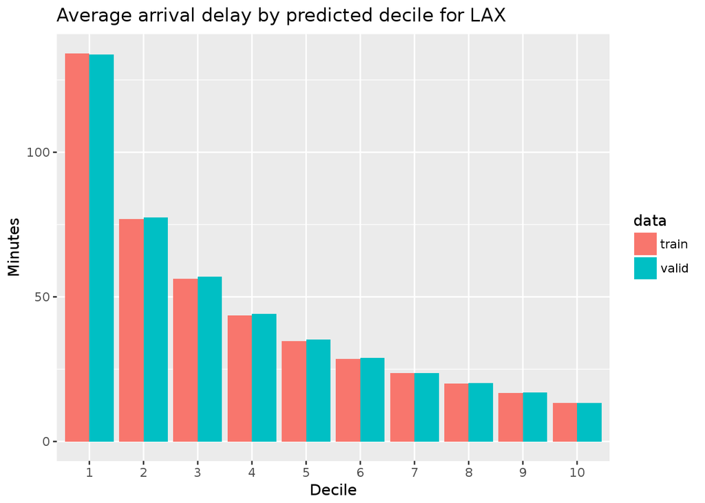

```r
deciles <- rbind(
  data.frame(data = 'train', model_deciles$train),
  data.frame(data = 'valid', model_deciles$valid),
  make.row.names = FALSE
)

deciles %>%
  ggplot(aes(factor(decile), arrdelay, fill = data)) +
  geom_bar(stat = 'identity', position = 'dodge') +
  labs(title = 'Average arrival delay by predicted decile for LAX', x = 'Decile',
       y = 'Minutes')
```

```r
test_flights_2008 <- flights_tbl %>%
  filter(origin == "LAX") %>%
    filter(!is.na(arrdelay) & !is.na(depdelay) & !is.na(distance)) %>%
  filter(depdelay > 15 & depdelay < 240) %>%
  filter(arrdelay > -60 & arrdelay < 360) %>%
  filter(year == 2008) %>%
  left_join(airlines_tbl, by = c("uniquecarrier" = "code")) %>%
    select(year, month, arrdelay, depdelay,
           distance, uniquecarrier, description)


carrier <- sdf_predict(ml2, test_flights_2008) %>%
  group_by(description) %>%
  summarize(arrdelay = mean(arrdelay), prediction = mean(prediction), freq = n()) %>%
  filter(freq > 1000) %>%
  collect()
```

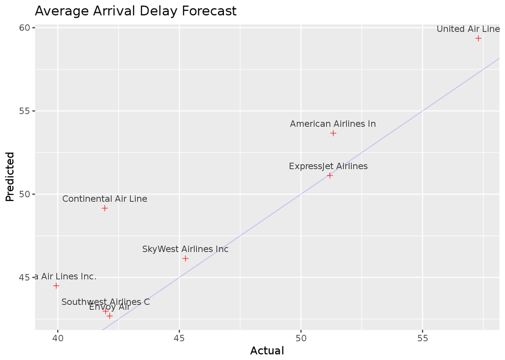

```r
ggplot(carrier, aes(arrdelay, prediction)) +
  geom_point(alpha = 0.75, color = 'red', shape = 3) +
  geom_abline(intercept = 0, slope = 1, alpha = 0.15, color = 'blue') +
  geom_text(aes(label = substr(description, 1, 20)), size = 3, alpha = 0.75, vjust = -1) +
  labs(title='Average Arrival Delay Forecast', x = 'Actual', y = 'Predicted')
```

**5. Visualize and explain any other information you want to explore.**

```r
# top 10 destinations
msp_top <- flights_tbl %>%
  filter(origin == "MSP" & !is.na(dest)) %>%
  select(origin, dest) %>%
  group_by(dest) %>%
  tally() %>%
  arrange(desc(n)) %>%
  collect() %>%
  top_n(10)
write_rds(msp_top, "msp_top.rds")

options(digits = 15)

msp_top_dest <- msp_top %>%
  left_join(airports_tbl, by = c("dest" = "faa"), copy = TRUE) %>%
  select(dest, n, lon, lat) %>%
  mutate(
    lon = as.double(lon),
    lat = as.double(lat)) %>%
  collect()

msp_top_dest
```

```
## # A tibble: 10 x 4
##    dest        n    lon   lat
##    <chr>   <dbl>  <dbl> <dbl>
##  1 ORD   249250.  -87.9  42.0
##  2 DEN   104019. -105.   39.9
##  3 DTW   103189.  -83.4  42.2
##  4 DFW    87972.  -97.0  32.9
##  5 ATL    85595.  -84.4  33.6
##  6 STL    81913.  -90.4  38.7
##  7 PHX    67707. -112.   33.4
##  8 EWR    63238.  -74.2  40.7
##  9 MDW    59532.  -87.8  41.8
## 10 MEM    55770.  -90.0  35.0
```

[figure not shown]

```r
usa1 <- map_data("usa")

us_map2 <- ggplot() +
  geom_polygon(data = usa1, aes(x = long, y = lat, group = group), fill = NA, color = "black") +
  coord_fixed(1.3) +
  guides(fill=FALSE)

us_map2 <- us_map2 +
  geom_point(data = lax_top_dest,
             aes(x = lon, y = lat, size = n/sum(n)),
             color = "blue")

us_map2 <- us_map2 +
  geom_label_repel(data = lax_top_dest,
                   aes(x = lon, y = lat, label = dest, size = n/sum(n),
                       fill = factor(dest)), min.segment.length = 0,
                   size = 3.5) +
  ggtitle("Top 10 Destinations from MSP")
us_map2
```

- ORD
- DEN
- DTW
- DFW
- ATL
- STL
- PHX
- EWR
- MDW
- MEM